# Data visualization: tSNE

05 November 2021

## Practical Session tSNE

Please, complete all the code proposed and answer to questions.

You will find these on the slides as (#) and (Q). You are not expected to include your answer to the check questions (C) or (K) knowledge thoughts. These are only to guide your progress.

Change the code appropriately or add new lines if necessary.

Load data into variables:

```r
# First of all, set your working directory if necessary.
setwd("C:/Users/aless/Desktop/Bioinformatics/Erasmus BCN/Data Visualisation/p2_tSNE")

# Read data & metadata
P1_data = read.delim('P1.tsv.gz', row.names = 1)
P2_data = read.delim('P2.tsv.gz', row.names = 1)

treat = as.factor(readLines('treatment.txt'))

# Check the data and that we read in the data correctly:
print(head(P1_data)[,1:5])
```

```
##                    P2449_N716.S502 P2449_N718.S502 P2449_N719.S502
## ENSG00000000003.14               0               0            0.00
## ENSG00000000005.5                0               0            0.00
## ENSG00000000419.12              43              53           91.00
## ENSG00000000457.13               1               0           20.33
## ENSG00000000460.16               2              89           26.67
## ENSG00000000938.12              15               0           16.00
##                    P2449_N720.S502 P2449_N721.S502
## ENSG00000000003.14               0               0
## ENSG00000000005.5                0               0
## ENSG00000000419.12              80              61
## ENSG00000000457.13               0               0
## ENSG00000000460.16               0             138
## ENSG00000000938.12               0               0
```

```r
print(head(P2_data)[,1:5])
```

```
##                    P2458_N701.S513 P2458_N702.S513 P2458_N703.S513
## ENSG00000000003.14               0            0.00            0.00
## ENSG00000000005.5                0            0.00            0.00
## ENSG00000000419.12               5           13.00           18.00
## ENSG00000000457.13               0            0.01            9.15
## ENSG00000000460.16              20           45.00           16.85
## ENSG00000000938.12               0            0.00            0.00
##                    P2458_N704.S513 P2458_N705.S513
## ENSG00000000003.14               0            0.00
## ENSG00000000005.5                0            0.00
## ENSG00000000419.12              26           10.00
## ENSG00000000457.13               0           33.99
## ENSG00000000460.16              82           10.01
## ENSG00000000938.12               0            0.00
```

```r
print(treat)
```

```
##  [1] N N N N N N U U U U U U U U U U U U U U U U U U U U U U U U U U U U U U T T
## [39] T T T T T T T T T T T T T T T T T T T T T T T T T T T T T T T T T T T T T T
## [77] T T T T T T T T T T T T T T T T T T T T
## Levels: N T U
```

```r
print(dim(P1_data))
```

```
## [1] 58441    96
```

```r
print(dim(P2_data))
```

```
## [1] 58441    96
```

```r
print(table(treat))
```

```
## treat
##  N  T  U
##  6 60 30
```

Adapt the data accordingly and merge both tables of observations. Since we need columns of the tables to represent variables and rows to be samples, individuals, we need to transpose the data of the matrices. Then, we merged experiments into a single data.frame.

```r
# Modify the matrices.
X1 = t(P1_data)
X2 = t(P2_data)

# Merge replicates
X = rbind(X1, X2)
```

Check that we transformed the data correctly:

```r
print(dim(X1))
```

```
## [1]    96 58441
```

```r
print(dim(X2))
```

```
## [1]    96 58441
```

```r
print(dim(X))
```

```
## [1]   192 58441
```

Get metadata associated:

```r
meta_data <- data.frame(row.names = rownames(X),
                        experiment= as.factor(rep(c("A","B"), each=96)),
                        treatment= treat)

head(meta_data)
```

```
##                 experiment treatment
## P2449_N716.S502          A         N
## P2449_N718.S502          A         N
## P2449_N719.S502          A         N
## P2449_N720.S502          A         N
## P2449_N721.S502          A         N
## P2449_N722.S502          A         N
```

Load package `Rtsne` and check the help. Run `install.packages("Rtsne")` if required.

```r
library(Rtsne)
help(Rtsne)
```

```
## starting httpd help server ... done
```

**Q1**. What are default values for perplexity, initial dimensions and iterations?

**A1**. The default values for perplexity, initial dimensions and iterations are 30, 50, and 1000 respectively.

A simple example of tSNE plot.

```r
## Default parametnes for Rtsne
tsne1 <- Rtsne(X)

## Check results generated
names(tsne1)
```

```
##  [1] "N"                   "Y"                   "costs"
##  [4] "itercosts"           "origD"               "perplexity"
##  [7] "theta"               "max_iter"            "stop_lying_iter"
## [10] "mom_switch_iter"     "momentum"            "final_momentum"
## [13] "eta"                 "exaggeration_factor"
```

```r
head(tsne1$Y)
```

```
##           [,1]      [,2]
## [1,] 1.9132505  9.531467
## [2,] 1.7791903 10.656333
## [3,] 0.9249228  8.674247
## [4,] 0.8892822  9.724729
## [5,] 1.7285023 10.353507
## [6,] 1.8892395 10.007840
```

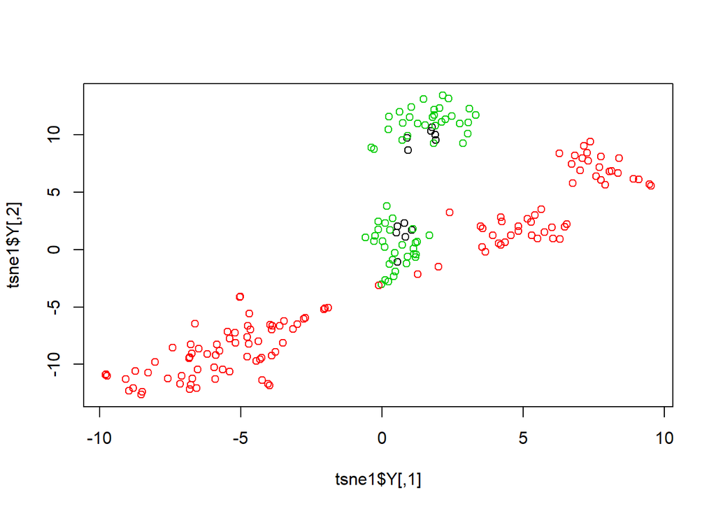

```r
## Basic R plot
plot(tsne1$Y, col=treat)

tsne_data <- as.data.frame(tsne1$Y)
tsne_data$Experiment <- meta_data$experiment
tsne_data$Treatment <- meta_data$treatment

## ggplot
library(ggplot2)
```

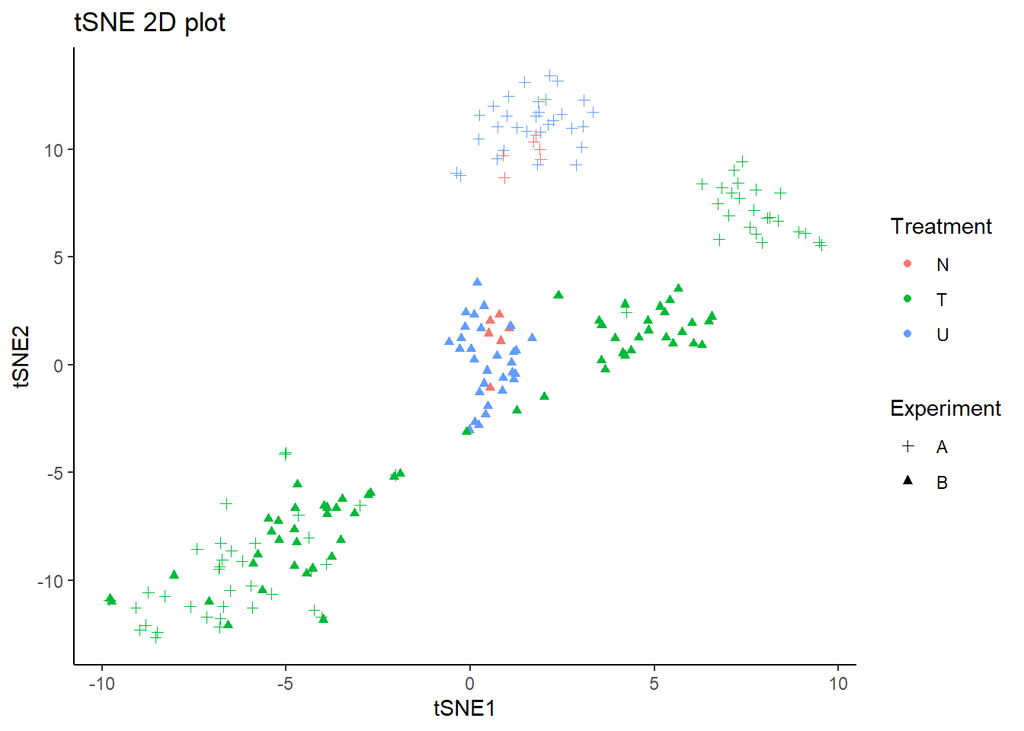

```r
ggplot(tsne_data, aes(x=V1, y=V2)) +
  geom_point(aes(color=Treatment, shape=Experiment)) +
  scale_shape_manual(values = c(3,17)) +
  ggtitle("tSNE 2D plot") + xlab("tSNE1") + ylab("tSNE2") +
  theme_classic()
```

**Explore reproducibility of results**

Run a second tSNE with the same dataset and parameters:

```r
tsne2 <- Rtsne(X)

names(tsne2)
```

```
##  [1] "N"                   "Y"                   "costs"
##  [4] "itercosts"           "origD"               "perplexity"
##  [7] "theta"               "max_iter"            "stop_lying_iter"
## [10] "mom_switch_iter"     "momentum"            "final_momentum"
## [13] "eta"                 "exaggeration_factor"
```

```r
head(tsne2$Y)
```

```
##          [,1]      [,2]
## [1,] 2.016449 -12.57724
## [2,] 1.849596 -13.45940
## [3,] 2.657004 -12.00911
## [4,] 2.802648 -12.87165
## [5,] 1.933079 -13.20315
## [6,] 1.825326 -12.74256
```

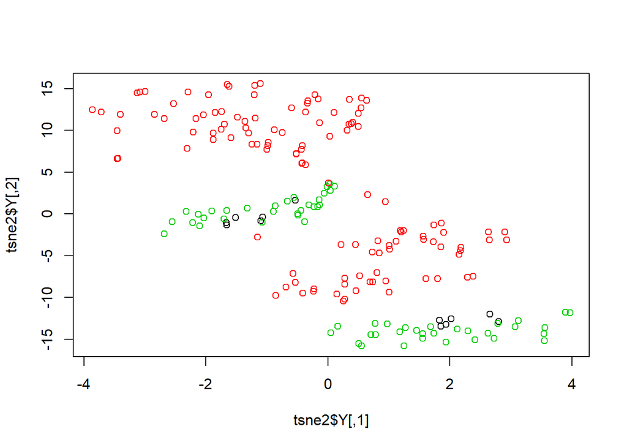

```r
plot(tsne2$Y, col=treat)
```

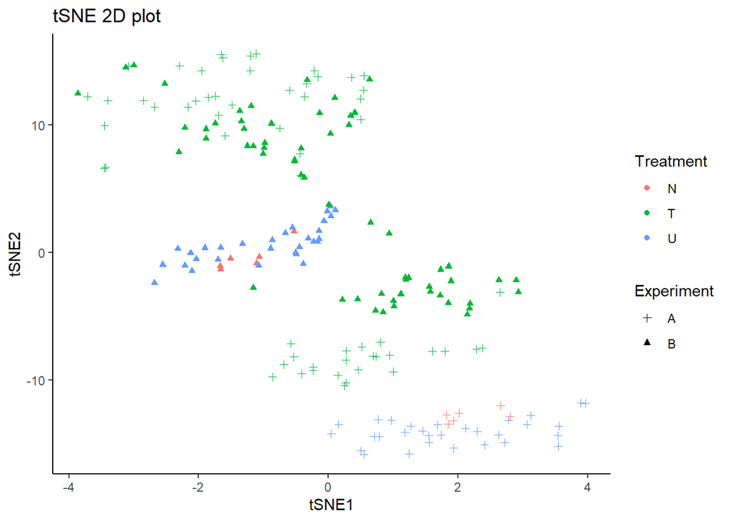

```r
tsne_data <- as.data.frame(tsne2$Y)
tsne_data$Experiment <- meta_data$experiment
tsne_data$Treatment <- meta_data$treatment

library(ggplot2)
ggplot(tsne_data, aes(x=V1, y=V2)) +
  geom_point(aes(color=Treatment, shape=Experiment)) +
  scale_shape_manual(values = c(3,17)) +
  ggtitle("tSNE 2D plot") + xlab("tSNE1") + ylab("tSNE2") +
  theme_classic()
```

**Q2**· Are `tsne1` and `tsne2` the same? Why?

**A2**. No, `tsne1` and `tsne2` are not identical, because tSNE generation is stochastic, the starting point in chosen randomly each time.

**Explore `pca=TRUE`**:

**Q3**. In the `Rtsne` function, what does the `pca` option mean?

**A1**. The `pca` option in the `tSNE` function determines whether an initial PCA step should be performed.

Run tSNE again and test the effect of setting `pca` to `TRUE/FALSE`.